# Estadística

Wilson Sandoval Rodriguez

2025-06-20

## HISTOGRAMAS DE FRECUENCIA RELATIVA

Un histograma de frecuencia relativa es semejante a una gráfica de barras, pero se usa para graficar cantidades en lugar de datos cualitativos.

#### Definición:

Un histograma de frecuencia relativa, para un conjunto de datos cuantitativo es una gráfica de barras en la que la altura de la barra muestra “con qué frecuencia” (medida como proporción o frecuencia relativa) las mediciones caen en una clase o subintervalo particular. Las clases o subintervalos se grafican a lo largo del eje horizontal.

Como regla práctica, el número de clases debe ser de 5 a 12; cuantos más datos haya, más clases se requieren.

Cuando los datos contienen una gran cantidad de elementos, para facilitar los cálculos es necesario agruparlos, a estos grupos se los llama **intervalos o clases.**

Las reglas generales para formas distribuciones de frecuencias para datos agrupados en intervalos son:

- Calcule el Rango (R): También se llama recorrido o amplitud total. Es la diferencia entre el valor mayor y el menor de los datos.
  $$Rango=Dato \ mayor - Dato \
  menor$$
- Seleccione el Número de Intervalos de Clase $(n_i)$.- No debe ser menor de 5 y mayor de 12,

## Regla de Sturges

Es una regla práctica acerca del número de clases que deben considerar al elaborarse un histograma

Este número viene dado por la siguiente expresión:

$$\displaystyle c=1+3.322\cdot \log
N$$

siendo N la cantidad de datos.

El valor de $c$ (número de clases) es común redondearlo al entero más cercano.

- Calcule el Ancho del Intervalo $(i)$

$$i=\dfrac{R}{n_{i}}$$

Cuando el valor de $i$ no es exacto, se debe redondear al valor superior más cercano. Esto altera el valor de rango por lo que es necesario efectuar un ajuste así:

$$Nuevo \ Rango= n_i \cdot i$$

#### Ejemplo

Pesos de 30 bebés de gestación completa al momento de nacer

$$\begin{array}{lllll}
7.2 & 7.8 & 6.8 & 6.2 & 8.2 \\
8.0 & 8.2 & 5.6 & 8.6 & 7.1 \\
8.2 & 7.7 & 7.5 & 7.2 & 7.7 \\
5.8 & 6.8 & 6.8 & 8.5 & 7.5 \\
6.1 & 7.9 & 9.4 & 9.0 & 7.8 \\
8.5 & 9.0 & 7.7 & 6.7 & 7.7
\end{array}$$

## Construcción Histograma

Escriba los datos en un vector

```r
Pesos<-c(7.2 , 7.8,  6.8 , 6.2,  8.2 ,8.0,  8.2, 5.6, 8.6, 7.1,
    8.2, 7.7, 7.5, 7.2, 7.7, 5.8,  6.8,  6.8,  8.5,  7.5,6.1,
    7.9, 9.4, 9.0, 7.8, 8.5, 9.0, 7.7, 6.7, 7.7)
```

## sin usar ggplot

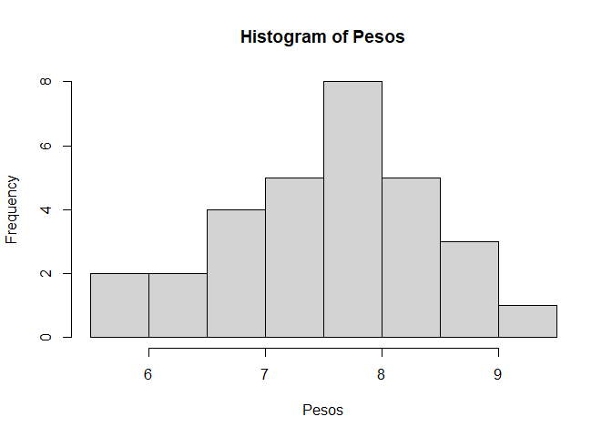

```r
hist(Pesos)
```

```r
minimo=min(Pesos)
minimo
```

```
## [1] 5.6
```

```r
maximo=max(Pesos)
maximo
```

```
## [1] 9.4
```

```r
range(Pesos)
```

```
## [1] 5.6 9.4
```

## con mas argumentos

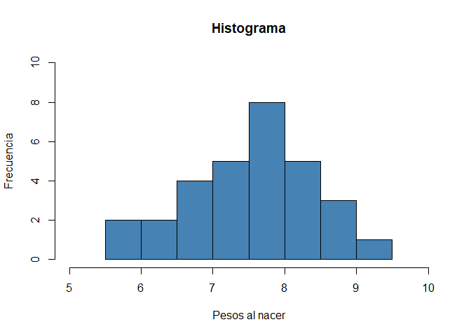

```r
hist(Pesos, xlim = c(5,10), ylim = c(0,10), main = "Histograma", xlab = "Pesos al nacer",
     ylab="Frecuencia", col="steelblue")
```

## tabla

instalar el paquete

```r
#install.packages("fdth")
library(fdth) # carga la extensión fdth (para el calculo de distribución de frecuencias.
```

## Calcula la distribución de frecuencias utilizando la regla Sturge

```r
dist <- fdt(Pesos,breaks="Sturges")
dist
```

```
##   Class limits f   rf rf(%) cf  cf(%)
##  [5.544,6.202) 4 0.13 13.33  4  13.33
##  [6.202,6.861) 4 0.13 13.33  8  26.67
##  [6.861,7.519) 5 0.17 16.67 13  43.33
##  [7.519,8.177) 8 0.27 26.67 21  70.00
##  [8.177,8.836) 6 0.20 20.00 27  90.00
##  [8.836,9.494) 3 0.10 10.00 30 100.00
```

## Con ggplot

```r
class(Pesos)
```

```
## [1] "numeric"
```

```r
df.Pesos<-as.data.frame(Pesos)  ###  CONVERTIR a data frame
df.Pesos
```

```
##    Pesos
## 1    7.2
## 2    7.8
## 3    6.8
## 4    6.2
## 5    8.2
## 6    8.0
## 7    8.2
## 8    5.6
## 9    8.6
## 10   7.1
## 11   8.2
## 12   7.7
## 13   7.5
## 14   7.2
```

[output cut: 16 more lines]

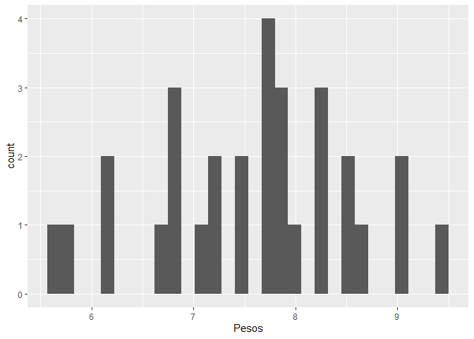

```r
library(ggplot2)
ggplot(data=df.Pesos , aes(Pesos))+
  geom_histogram()
```

## Mejorando el histograma

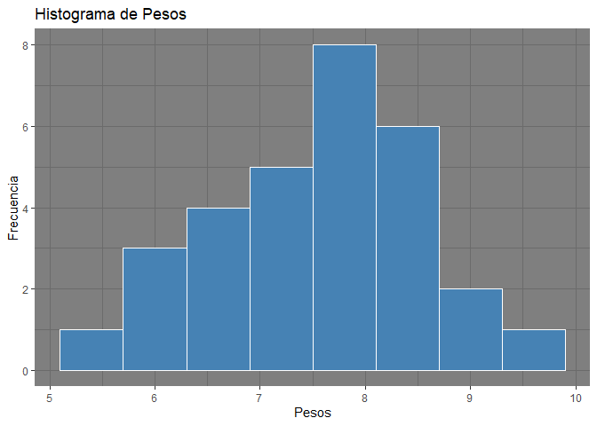

```r
ggplot(data=df.Pesos,aes(Pesos))+
  geom_histogram(binwidth = 0.6,  fill = 'steelblue', color="white") +
  xlab("Pesos") +
  ylab("Frecuencia") +
  ggtitle("Histograma de Pesos") +
  theme_dark()
```

Con una base de R

```r
library(MASS)
data(Cars93)
attach(Cars93)
```

```r
names(Cars93)
```

```
##  [1] "Manufacturer"       "Model"              "Type"
##  [4] "Min.Price"          "Price"              "Max.Price"
##  [7] "MPG.city"           "MPG.highway"        "AirBags"
## [10] "DriveTrain"         "Cylinders"          "EngineSize"
## [13] "Horsepower"         "RPM"                "Rev.per.mile"
## [16] "Man.trans.avail"    "Fuel.tank.capacity" "Passengers"
## [19] "Length"             "Wheelbase"          "Width"
## [22] "Turn.circle"        "Rear.seat.room"     "Luggage.room"
## [25] "Weight"             "Origin"             "Make"
```

```r
str(Cars93)
```

```
## 'data.frame':    93 obs. of  27 variables:
##  $ Manufacturer      : Factor w/ 32 levels "Acura","Audi",..: 1 1 2 2 3 4 4 4 4 5 ...
##  $ Model             : Factor w/ 93 levels "100","190E","240",..: 49 56 9 1 6 24 54 74 73 35 ...
##  $ Type              : Factor w/ 6 levels "Compact","Large",..: 4 3 1 3 3 3 2 2 3 2 ...
##  $ Min.Price         : num  12.9 29.2 25.9 30.8 23.7 14.2 19.9 22.6 26.3 33 ...
##  $ Price             : num  15.9 33.9 29.1 37.7 30 15.7 20.8 23.7 26.3 34.7 ...
##  $ Max.Price         : num  18.8 38.7 32.3 44.6 36.2 17.3 21.7 24.9 26.3 36.3 ...
##  $ MPG.city          : int  25 18 20 19 22 22 19 16 19 16 ...
##  $ MPG.highway       : int  31 25 26 26 30 31 28 25 27 25 ...
##  $ AirBags           : Factor w/ 3 levels "Driver & Passenger",..: 3 1 2 1 2 2 2 2 2 2 ...
##  $ DriveTrain        : Factor w/ 3 levels "4WD","Front",..: 2 2 2 2 3 2 2 3 2 2 ...
##  $ Cylinders         : Factor w/ 6 levels "3","4","5","6",..: 2 4 4 4 2 2 4 4 4 5 ...
##  $ EngineSize        : num  1.8 3.2 2.8 2.8 3.5 2.2 3.8 5.7 3.8 4.9 ...
##  $ Horsepower        : int  140 200 172 172 208 110 170 180 170 200 ...
##  $ RPM               : int  6300 5500 5500 5500 5700 5200 4800 4000 4800 4100 ...
##  $ Rev.per.mile      : int  2890 2335 2280 2535 2545 2565 1570 1320 1690 1510 ...
##  $ Man.trans.avail   : Factor w/ 2 levels "No","Yes": 2 2 2 2 2 1 1 1 1 1 ...
##  $ Fuel.tank.capacity: num  13.2 18 16.9 21.1 21.1 16.4 18 23 18.8 18 ...
##  $ Passengers        : int  5 5 5 6 4 6 6 6 5 6 ...
##  $ Length            : int  177 195 180 193 186 189 200 216 198 206 ...
##  $ Wheelbase         : int  102 115 102 106 109 105 111 116 108 114 ...
##  $ Width             : int  68 71 67 70 69 69 74 78 73 73 ...
##  $ Turn.circle       : int  37 38 37 37 39 41 42 45 41 43 ...
##  $ Rear.seat.room    : num  26.5 30 28 31 27 28 30.5 30.5 26.5 35 ...
##  $ Luggage.room      : int  11 15 14 17 13 16 17 21 14 18 ...
##  $ Weight            : int  2705 3560 3375 3405 3640 2880 3470 4105 3495 3620 ...
##  $ Origin            : Factor w/ 2 levels "USA","non-USA": 2 2 2 2 2 1 1 1 1 1 ...
##  $ Make              : Factor w/ 93 levels "Acura Integra",..: 1 2 4 3 5 6 7 9 8 10 ...
```

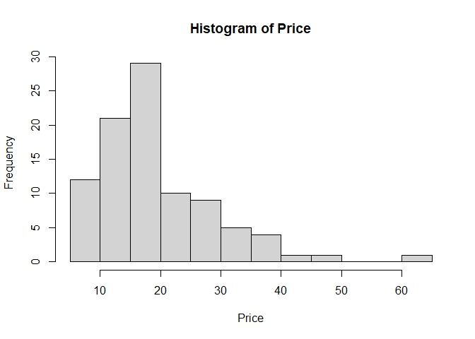

```r
hist(Price)
```

```r
?geom_histogram
```

```
## starting httpd help server ... done
```

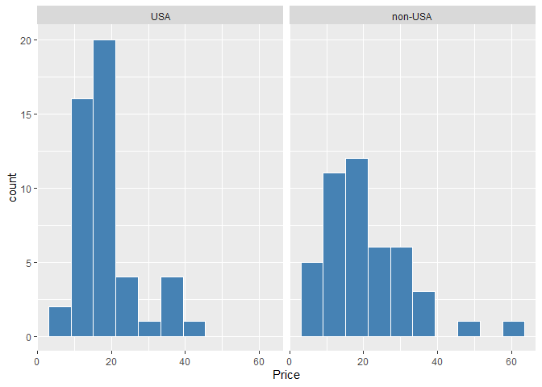

```r
ggplot(data=Cars93, aes(Price))+
  geom_histogram(color="white", fill="steelblue", bins = 10)+
  facet_wrap(~Origin)
```

## MEDIDAS DE CENTRO

Una de las primeras mediciones numéricas importantes es una **medida de centro**, es decir, una medida a lo largo del eje horizontal que localiza el centro de la distribución.

#### Definición:

La media aritmética o promedio de un conjunto de $n$ mediciones es igual a la suma de las mediciones dividida entre $n$.

Media muestral: $\overline{x}=\dfrac{\sum_{i=1}^{n} x_{i}}{n}$

Media poblacional: $\mu$

```r
v1=c(2,9,11,5,6, 100)
mean(v1)
```

```
## [1] 22.16667
```

#### Definición

La mediana $m$ de un conjunto de $n$ mediciones es el valor de x que cae en la posición media cuando las mediciones son ordenadas de menor a mayor.

- **Ejemplo:**

Encuentre la mediana para el conjunto de mediciones 2, 9, 11, 5, 6, 27.

```r
v2 = c(2,9,11,5,6,27)
median(v2)
```

```
## [1] 7.5
```

### Definición

La moda es la categoría que se presenta con más frecuencia o el valor de $x$ que se presenta con más frecuencia. Cuando las mediciones en una variable continua se han agrupado como histograma de frecuencia o de frecuencia relativa, la clase con el pico más alto o frecuencia se llama clase modal, y el punto medio de esa clase se toma como la moda

3, 5, 4, 6, 10, 5, 6, 9, 2, 8.

Calcule

- $\overline{x}$
- Encuentre mediana.
- Encuentre la moda.

## MEDIDAS DE VARIABILIDAD

Una medida de dispersión o variabilidad nos determina el grado de acercamiento o distanciamiento de los valores de una distribución frente a su promedio de localización, sobre la base de que entre más grande sea el grado de variación menor uniformidad tendrán los datos (sinónimo de heterogeneidad) y por lo tanto menor representatividad o confiabilidad del promedio de tendencia central o localización por haber sido obtenido de datos dispersos. Por el contrario, si este valor es pequeño (respecto a la unidad de medida) entonces hay una gran uniformidad entre los datos. Cuando es cero quiere decir que todos los datos son iguales.

Hay básicamente dos tipos de medidas de dispersión: Medidas Absolutas y Medidas Relativas. Las absolutas se caracterizan por ser números concretos, es decir, valores expresados en las mismas unidades de la variable en estudio y que por lo tanto no permiten comparaciones o análisis respecto a la mayor o menor dispersión de series expresadas en diferentes unidades. Estas medidas son: la varianza, la desviación estándar y el rango intercuartilico.

Las medidas relativas de dispersión son valores abstractos, es decir, medidas adimensionales y por lo tanto no expresadas en ninguna unidad especifica, obviando así el inconveniente señalado para las medidas absolutas. La principal medida es el coeficiente de variación.

**La variabilidad o dispersión** es una muy importante característica de datos. Por ejemplo, si usted fabrica tornillos, la variación extrema en los diámetros de los tornillos causaría un alto porcentaje de productos defectuosos.

**Las medidas de variabilidad** pueden ayudarle a crear una imagen mental de la dispersión de los datos.

##### Definición:

El rango, $R$, de un conjunto de $n$ mediciones se define como la diferencia entre la medición más grande y la más pequeña.

#### Definición

**La varianza de una población** de $N$ mediciones es el promedio de los cuadrados de las desviaciones de las mediciones alrededor de su media $\mu$. La varianza poblacional se denota con $\sigma^2$ y está dada por.

$$\sigma^2=\dfrac{\sum_{i=1}^{N}
(x_i-\mu)^2}{N}$$

#### Definición:

La varianza de una muestra de $n$ mediciones es la suma de las desviaciones cuadradas de las mediciones alrededor la media $\overline{x}$ dividida entre $(n - 1)$. La varianza muestral se denota con $S^2$ y está dada por la fórmula

$$\displaystyle S^2=\dfrac{\sum_{i=1}^{n}
(x_i-\overline{x})^2}{n-1}$$

#### Definición

La desviación estándar de un conjunto de mediciones es igual a la raíz cuadrada positiva de la varianza.

### Ejemplo

Hallar la desviación estandar,

- 2, 3, 6, 8, 11.
- 12, 6, 7, 3, 15, 10, 18, 5.

Ctr +ALT + i

```r
v3=c(2,3,6,8,11)
sd(v3)
```

```
## [1] 3.674235
```

## MEDICIONES DE POSICIÓN RELATIVA

A veces es necesario conocer la posición de una observación respecto a otras de un conjunto de datos.

### Definición:

El puntaje $z$ muestral es una medida de posición relativa definida por

$$puntaje \ \ z =
\dfrac{x-\overline{x}}{s}$$

Un puntaje $z$ mide la distancia entre una observación y la media, medidas en unidades de desviación estándar.

El puntaje z es una valiosa herramienta para determinar si es probable que una observación particular se presente con frecuencia, o si es improbable y puede ser considerada como resultado atípico

Considere esta muestra de 10 mediciones:

1, 1, 0, 15, 2, 3, 4, 0, 1, 3

```r
v4=c(1, 1, 0, 15, 2, 3, 4, 0, 1, 3)

z=(v4-mean(v4))/sd(v4)
z
```

```
##  [1] -0.4522670 -0.4522670 -0.6784005  2.7136021 -0.2261335  0.0000000
##  [7]  0.2261335 -0.6784005 -0.4522670  0.0000000
```

```r
scale(v4)
```

```
##             [,1]
##  [1,] -0.4522670
##  [2,] -0.4522670
##  [3,] -0.6784005
##  [4,]  2.7136021
##  [5,] -0.2261335
##  [6,]  0.0000000
##  [7,]  0.2261335
##  [8,] -0.6784005
##  [9,] -0.4522670
## [10,]  0.0000000
## attr(,"scaled:center")
## [1] 3
## attr(,"scaled:scale")
## [1] 4.422166
```

- **Un percentil** es otra medida de posición relativa y se usa con más frecuencia para conjuntos grandes de datos. (Los percentiles no son muy útiles para conjuntos pequeños de datos.)

#### Definición:

Un conjunto de $n$ mediciones de la variable $x$ se ha reacomodado en orden de magnitud. **El $p$-ésimo percentil** es el valor de $x$ que es mayor a $p$% de las mediciones y es menor que el restante $(100 - p)$%.

#### Definición

Un conjunto de $n$ mediciones en la variable $x$ se ha acomodado en orden de magnitud.

- El **cuartil inferior** (primer cuartil), $Q_1$, es el valor de $x$ que es mayor a un cuarto de las mediciones y es menor que los restantes tres cuartos.
- El segundo cuartil es la mediana.
- El cuartil superior (tercer cuartil), $Q_3$, es el valor de $x$ que es mayor a tres cuartos de las mediciones y es menor que el restante un cuarto.
- El rango intercuartil **IQR** para un conjunto de mediciones es la diferencia entre los cuartiles superior e inferior; esto es,
  $$IQR = Q_3 - Q_1$$
  .

El procedimiento para encontrar el valor de cualquier percentil a partir de datos clasificados, es el siguiente:

- Encontrar la posición $i$ del percentil $k-ésimo$ mediante el calculo de $nk$.
- Si $nk$ no es un entero, entonces la posición $i$ es el siguiente entero más grande y entonces el valor de $p_k$ es el dato ordenado en la posición de este entero más grande.
- Si $nk$ es un entero, entonces la posición del percentil será $i=nk+0.5$yasí el valor del percentil es el promedio de las observaciones ordenadas $nk$ y $nk+1$

#### Ejemplo

A continuación se presentan 20 observaciones en orden del tiempo de falla, en horas, de un material aislante eléctrico (adaptadas del trabajo de Nelson, Applied Life Data Analysis, 1982):

204 228 252 300 324 444 624 720 816 912 1176 1296 1392 1488 1512 2520 2856 3192 3528 3710

Para encontrar el percentil 10, $p_{0.10}$, el valor de $nk=20(0.10=2)$, es un entero, el número de la posición es , el cual es el promedio de las observaciones segunda y tercera. Por tanto, el percentil $p_{10}=\frac{228+252}{2}=240$ es, lo cual significa que el 10% de los tiempos de fallas del material electrico aislante es aproximadamente inferior a 240 horas.

El percentil 88 se encuentra de manera similar. Puesto que ahora k=0.88, $nk=20(0.88)=17.6$, que no es un entero, y el número de la posición es $i=18$. Por tanto, el percentil 88 es la observación ordenada número 18, esto es $p_{0.88}=3192$; es decir el 88% de los tiempos de fallas del material electrico aislante es aproximadamente inferior a 3192 horas.

```r
e=c(204,    228,    252,    300,    324,    444,    624,    720,    816,    912,1176,   1296,   1392,   1488,   1512,   2520,   2856,   3192,
    3528,   3710)

quantile(e,0.5)
```

```
##  50%
## 1044
```

```r
#median(e)
```

### Ejercicios Propuestos

- Suponga que las notas de los estudiantes de un curso en un examen parcial tuvo una media aritmética de 3.5, pero el profesor decide colocar como nueva nota, el 80% de su nota anterior más uno. ¿ Cúal es la nueva nota promedio del curso?. (esta transformación es conocida como la curva del ocho).
- ¿ Cómo se encuentran ubicados la media, la mediana y la moda cuando la distribución es simétrica, sesgada a la derecha o sesgada a la izquierda?.
- Determine un conjunto de datos tales que:
  - La media, mediana y moda sean iguales
  - La mediana sea mayor que la media
  - La media sea mayor que la mediana. -Para cada uno de los conjuntos de datos del numeral anterior, encuentre los cuartiles 1, 2 y 3 e interprételos

#### **Ejemplo**

A medida que los consumidores estadounidenses tienen más cuidado con los alimentos que consumen, los procesadores de alimentos tratan de ser competitivos al evitar cantidades excesivas de grasa, colesterol y sodio en los alimentos que venden. Los datos siguientes son las cantidades de sodio por rebanada (en miligramos) para cada una de ocho marcas de queso regular estadounidense. Construya una gráfica de caja para los datos y busque resultados atípicos.\

340, 300, 520, 340, 320, 290, 260, 330

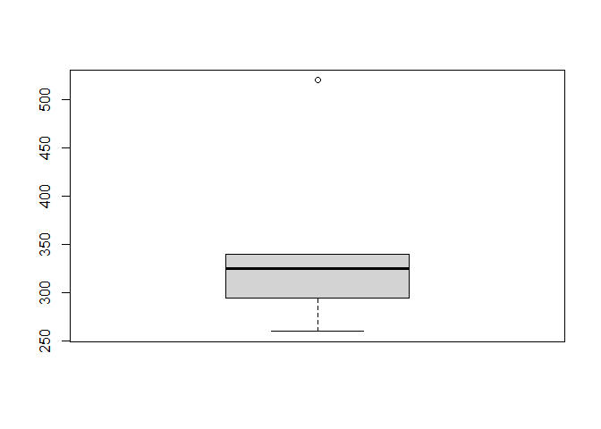

```r
sodio=c(340, 300, 520, 340, 320, 290, 260, 330)
boxplot(sodio)
```

```r
summary(sodio)
```

```
##    Min. 1st Qu.  Median    Mean 3rd Qu.    Max.
##   260.0   297.5   325.0   337.5   340.0   520.0
```

Con nuestra base de datos de R

```r
colnames(Cars93)
```

```
##  [1] "Manufacturer"       "Model"              "Type"
##  [4] "Min.Price"          "Price"              "Max.Price"
##  [7] "MPG.city"           "MPG.highway"        "AirBags"
## [10] "DriveTrain"         "Cylinders"          "EngineSize"
## [13] "Horsepower"         "RPM"                "Rev.per.mile"
## [16] "Man.trans.avail"    "Fuel.tank.capacity" "Passengers"
## [19] "Length"             "Wheelbase"          "Width"
## [22] "Turn.circle"        "Rear.seat.room"     "Luggage.room"
## [25] "Weight"             "Origin"             "Make"
```

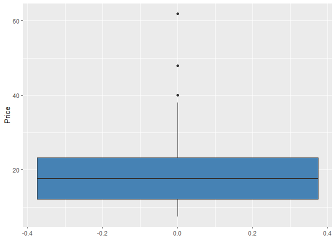

```r
ggplot(data=Cars93, aes(y=Price))+
  geom_boxplot(fill="steelblue")
```

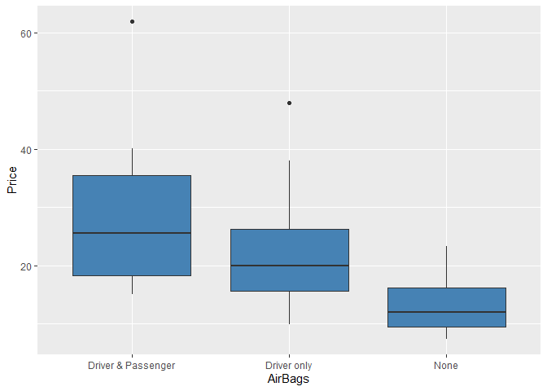

```r
ggplot(data=Cars93, aes(y=Price, x=AirBags))+
  geom_boxplot(fill="steelblue")
```

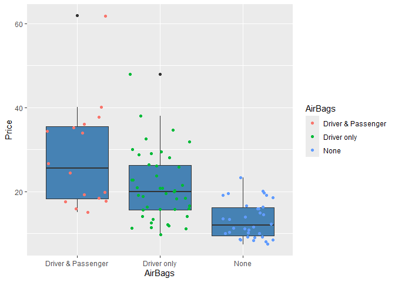

```r
ggplot(data=Cars93, aes(y=Price, x=AirBags))+
  geom_boxplot(fill="steelblue")+
  geom_jitter(aes(color = AirBags))
```

```r
quantile(Price,0.5)
```

```
##  50%
## 17.7
```

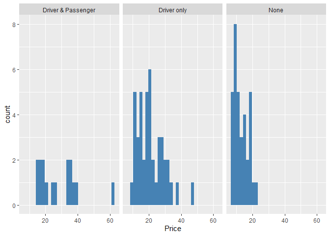

```r
 ggplot(data = Cars93, aes(x = Price))+
  geom_histogram(fill="steelblue")+
  facet_wrap(~AirBags)
```

## Diagrama de dispersión

### Definición:

Solo para variables cuantitativas, permite ver como es el comportamiento de dos variables en lo que se conoce como una nube de puntos

[figure not shown]

## Medidas enntre dos variables

#### Covarianza

La covarianza $s_{x y}$ es una medida que indica la variabilidad conjunta de dos variables cuantitativas y se define como:
$$s_{x y}=\frac{1}{n}
\sum_{i=1}^{n}\left(x_{i}-\bar{x}\right)\left(y_{i}-\bar{y}\right)$$

- Si $s_{xy} > 0$ las dos variables crecen o decrecen a la vez.
- Si $s_{xy} < 0$ una variable crece mientras que la otra decrece.
- Si $s_{xy} = 0$ no hay relación lineal entre las variables.

## Coeficiente de correlación lineal de Pearson

#### Definición

La covarianza está afectada por los cambios de unidad de medida. Se define el coeficiente de correlación lineal de Pearson como:

$$r=\frac{s_{x y}}{s_{x}
s_{y}}=\frac{\frac{1}{n}
\sum_{i=1}^{n}\left(x_{i}-\bar{x}\right)\left(y_{i}-\bar{y}\right)}{\sqrt{\frac{1}{n}
\sum_{i=1}^{n}\left(x_{i}-\bar{x}\right)^{2}} \sqrt{\frac{1}{n}
\sum_{i=1}^{n}\left(y_{i}-\bar{y}\right)^{2}}}$$

### Características del coeficiente de correlación

- Es adimensional.
- Es invariante a los cambios de escala.
- Toma valores entre -1 y 1.
- Indica fuerte relación lineal entre variables cuando $|r|$ es cercano a 1.
- Si es cercano a 0, puede afirmarse que no existe relación lineal entre ambas variables.

## Ejemplo

Se tienen los siguientes conjuntos de datos $X=\{5,8,9,10,15\}$ cuya media es $\bar{x}=9.4$ y $Y=\{0.1,0.4,0.5,0.9,0.99\}$ cuya media es $\bar{y}=0.578$

$$\begin{array}{|c|c|c|c|c|}
\hline X & Y & \left(x_{i}-\bar{x}\right)^{2} &
\left(y_{i}-\bar{y}\right)^{2} &
\left(x_{i}-\bar{x}\right)\left(y_{i}-\bar{y}\right) \\
\hline 5 & 0.1 & 19.36 & 0.2285 & 2.1032 \\
\hline 8 & 0.4 & 1.96 & 0.0317 & 0.2492 \\
\hline 9 & 0.5 & 0.16 & 0.0061 & 0.0312 \\
\hline 10 & 0.9 & 0.36 & 0.1037 & 0.1932 \\
\hline 15 & 0.99 & 31.36 & 0.1697 & 2.3072 \\
\hline & Suma & 53.20 & 0.5397 & 4.884 \\
\hline
\end{array}$$

De la tabla anterior:
$$s_{x y}=\frac{4.884}{5}=0.9768$$

- $s_{x}^{2}=\frac{53.2}{5}=10.64 \Rightarrow s_{x}=3.2619$
- $s_{y}^{2}=\frac{0.5397}{5}=0.1079 \Rightarrow s_{y}=0.3285$ De donde,
  $$r=\frac{0.9768}{(3.2619)(0.3285)}$$

## La regresión

En míltiples estudios estadísticos, aparece la necesidad práctica de considerar simultáneamente dos o más variables, con el fin de analizar si entre ellas existe alguna relación, si la manera se puede formalizar y qué tan intensa es la misma

El supuesto de partida considera que algunas de las variables explican en parte, el comportamiento de otras. Se establece una división general entre las variables clasificándolas en dos grupos constituidos por las variables independientes o explicativas y las variables explicadas o respuesta

## Regresión

Un artículo en el Journal of Sound and Vibration (Vol. 151, 1991, pp. 383-394) describe un estudio que investiga la relación entre la exposición al ruido y la hipertensión. Los siguientes datos son representativos de los reportados en el artículo.

$$\begin{array}{ccccc}
x & y & x & y \\
\hline 60 & 1 & 85 & 5 \\
63 & 0 & 89 & 4 \\
65 & 1 & 90 & 6 \\
70 & 2 & 90 & 8 \\
70 & 5 & 90 & 4 \\
70 & 1 & 90 & 5 \\
80 & 4 & 94 & 7 \\
90 & 6 & 100 & 9 \\
80 & 2 & 100 & 7 \\
80 & 3 & 100 & 6 \\
\hline
\end{array}$$

Aquí la variable $y$ representa el aumento de la presión arterial en milímetros de mercurio y la variable $x$ representa el nivel de presión acústica en decibeles.

Si consideramos que $y$ representa la presión arterial y $x$ representa la presión acústica, entonces la ecuación de una línea recta que relaciona estas dos variables es

$$\begin{equation}
y = \beta_0 + \beta_1 x
\end{equation}$$

- $\beta_0$ es el intercepto y
- $\beta_1$ es la pendiente.